# Lab #14 - Confidence Intervals

$~$

This lab covers confidence interval estimation using the two approaches described in our most recent lecture:

1. Bootstrapping
2. Probability Models

These methods can be applied to any of the descriptive statistics we’ve seen throughout the semester, including the coefficients of regression models.

```r
## Data that will be used in examples (claims against the TSA for laptops)
library(dplyr)
tsa <- read.csv("https://remiller1450.github.io/data/tsa.csv")
tsa_laptops = tsa %>% filter(Item == "Computer - Laptop", Claim_Amount < 1e6)
```

$~$

### Confidence Intervals using Probability Models

We’ve already seen the functions needed to create confidence interval estimates for many common scenarios. As review, these functions are summarized in the table below:

[output not shown]

You should note that each function expects a different type of input. Below are a few quick examples so you don’t need to go back to our previous labs.

```r
## For prop.test() "x" is the numerator(s) and "n" is the denominator(s) of the involved proportions
numerator_count = sum(tsa_laptops$Status == "Denied")
denominator_count = length(tsa_laptops$Status)
prop.test(x = numerator_count, n = denominator_count, correct = FALSE)


## For t.test() "x" is either the variable (one-sample) or a formula of the form `outcome ~ explanatory` and "data" is the data set.
t.test(x = tsa_laptops$Claim_Amount)

## For cor.test() "x" and "y" are each of the two involved variables
cor.test(x = tsa_laptops$Claim_Amount, y = tsa_laptops$Close_Amount)


## For confint() "object" is the fitted regression model
fitted_model = lm(Close_Amount ~ Claim_Amount, data = tsa_laptops)
confint(fitted_model)
```

[output not shown]

With all of these functions, the *confidence level* can be adjusted using the `conf.level` argument (except for `confint()`, which uses the `level` argument).

```r
## Example of a 99% confidence interval
cor.test(x = tsa_laptops$Claim_Amount, y = tsa_laptops$Close_Amount, conf.level = 0.99)
```

```
##
##  Pearson's product-moment correlation
##
## data:  tsa_laptops$Claim_Amount and tsa_laptops$Close_Amount
## t = 4.7439, df = 1593, p-value = 2.284e-06
## alternative hypothesis: true correlation is not equal to 0
## 99 percent confidence interval:
##  0.05396995 0.18111678
## sample estimates:
##       cor
## 0.1180271
```

**Question #1**: [Michael Jordan](https://en.wikipedia.org/wiki/Michael_Jordan) is widely regarded as the best professional basketball player of all time. At the end of his playing career after the 2002-03 NBA season he averaged 30.1 points per game in his regular season appearances. In this question you will consider *three different random samples* of varying sizes ($n=5$, $n=25$, and $n=75$) of regular season games played by Michael Jordan.

```r
mj5 = read.csv("https://remiller1450.github.io/data/mj5.csv")
mj25 = read.csv("https://remiller1450.github.io/data/mj25.csv")
mj75 = read.csv("https://remiller1450.github.io/data/mj75.csv")
```

- **Part A**: For the `mj75` sample ($n=75$ games) use the `mean()` and `sd()` functions to find the sample mean and sample standard deviation for the number of points per game scored by Michael Jordan.
- **Part B**: Use [StatKey](https://lock5stat.com/StatKey/) to find the calibration constant, $c$, for a 95% confidence interval. Note that because the outcome here is quantitative you should be using a $t$-distribution.
- **Part C**: Compute the margin of error for the 95% confidence interval referenced in Part A.
- **Part D**: Consider the `mj5` and `mj25` samples. Without calculating anything, if you were to compute the margin of error for a 95% confidence interval for the mean number of points per game scored by Michael Jordan, how would you expect the size of each margin of error to compare with the one you found in Part C? Order the margins of error from smallest to largest according to your expectation and briefly justify your ordering.
- **Part E**: Michael Jordan’s actual career average points per game is 30.1. Without computing the endpoints of any interval, which do you think is most likely to contain this true population mean? Briefly explain your thought process.
- **Part F**: Suppose the confidence level in this application was increased from 95% to 99%, how would this impact the width of each interval? How would it impact the expected accuracy of each interval?

$~$

**Question #2**: For this question you should continue using the `mj75` sample. This question will involve a variety of different research questions and your task is to find the requested confidence interval estimate for the relevant population parameter using an appropriate `R` function.

- **Part A**: Suppose you would like to describe the relationship between the number of turnovers Michael Jordan commits (variable `tov`) and the number of points he scores. Find a *90% confidence interval estimate* for an appropriate descriptive statistic. Be sure you explore the data to determine the appropriate statistic.
- **Part B**: According to the interval you found in Part A, is it plausible that these variables are unrelated?
- **Part C**: Suppose you would like to assess whether Michael Jordan on average scored a different number of points when playing for the Washington Wizards than he did when playing for the Chicago Bulls. Find a *99% confidence interval estimate* for this difference.
- **Part D**: According to the interval you found in Part C, is it plausible that the involved variables are unrelated?
- **Part E**: Use the `lm()` function to fit a simple linear regression model that uses the `stl`, the number of steals, to predict `pts`. Then use the `confint()` function to find a 95% confidence interval estimate for the slope coefficient.
- **Part F**: According to the interval you found in Part E, is it plausible that the involved variables are unrelated?

$~$

### Bootstrapping in `R`

StatKey provides an intuitive UI to see the results of bootstrapping, but in a real-world setting it is valuable to perform an analysis that is entirely reproducible via `R`.

To use bootstrapping to construct a confidence interval, we first need to obtain many bootstrap samples from the original dataset. We can do this by using a *for loop* to repeatedly apply the `sample()` function with the argument `replace = TRUE` to sample our dataset with replacement.

The example below bootstraps the correlation between `AvgMovingSpeed` and `TotalTime` in the “commute tracker” dataset we saw in our lecture slides:

```r
## Load the real sample data
commute_tracker = read.csv("https://remiller1450.github.io/data/CommuteTracker.csv")
my_dataset = commute_tracker

## Setup
n_boot = 1000                # number of bootstrap samples to draw
n = nrow(my_dataset)    # size of the real sample
boot_stats = numeric(n_boot) # empty object to store bootstrapped statistics

## Draw each sample and store the bootstrapped statistic
for(i in 1:n_boot){

  ## Use the sample function to identify which cases are selected in the bootstrap sample
  case_idx = sample(x = 1:n, size = n, replace = TRUE)

  ## Put the selected cases into a data frame
  cur_boot_sample = my_dataset[case_idx, ]

  ## Calculate the descriptive statistic of interest (correlation) for the current bootstrap sample
  boot_stats[i] = cor(x=cur_boot_sample$AvgMovingSpeed, y=cur_boot_sample$TotalTime)
}
```

The object `boot_stats` stores the statistic of interest (sample correlation) for 1000 different bootstrap samples. We can plot the bootstrap distribution to get a sense of how much this correlation might vary from one sample to another:

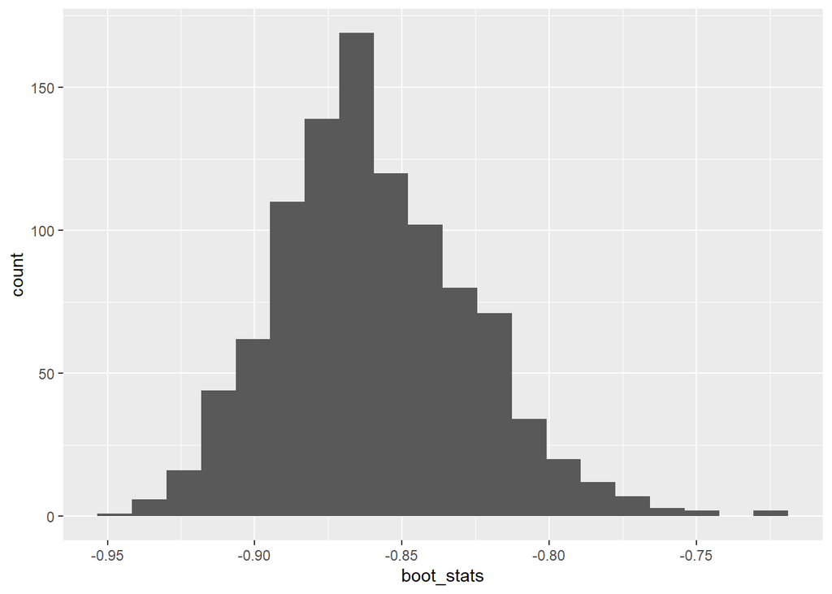

```r
library(ggplot2)
ggplot() + geom_histogram(aes(x = boot_stats), bins = 20)
```

To find a *$P\%$ percentile bootstrap confidence interval* we need to find the relevant percentiles that define the middle $P\%$ of the bootstrap distribution, which we can do using the `quantile()` function:

```r
quantile(boot_stats, probs = c(0.005, 0.995))
```

```
##       0.5%      99.5%
## -0.9349234 -0.7555941
```

The above code gives us a 99% confidence interval estimate because it excludes the most extreme 1% of bootstrapped results (0.5% on each end of the bootstrap distribution).

If we had instead wanted a 95% confidence interval we simply need to modify the `probs` argument to reflect the middle 95% of bootstrapped samples:

```r
quantile(boot_stats, probs = c(0.025, 0.975))
```

```
##       2.5%      97.5%
## -0.9168570 -0.7890995
```

**Question #3**: For this question you will consider only the `mj25` sample of Michael Jordan’s games.

```r
mj25 = read.csv("https://remiller1450.github.io/data/mj25.csv")
```

- **Part A**: Consider the bootstrapping code provided as an example in this section. Aside from changing the dataset, what is the only line of code that will need to change to adapt this example to bootstrap the mean number of points per game? How would you change it?
- **Part B**: Implement the change you identified in Part A and find a 95% percentile bootstrap confidence interval for the mean number of points per game. Note that you should find the endpoints of this interval using the `quantile()` function with the appropriate values for the `probs` argument.
- **Part C**: Use the `t.test()` function to compute a 95% confidence interval using the probability model approach for the mean number of points per game scored by Michael Jordan. How do the endpoints of this interval compare with those you found using bootstrapping in Part B?
- **Part D**: Graph a histogram of the bootstrap distribution involved in Part A and B. Briefly comment on how the shape of this histogram relates to how similar/different you found the percentile bootstrap and probability model confidence intervals to be in Part C.

$~$

### Application

Many scholars define a mass shooting as an incident where four or more people are shot and either injured or killed in a short period of time. The [Gun Violence Archive](https://www.gunviolencearchive.org/reports/mass-shooting) maintains a database of mass shootings that have happened in the United States. The data below are the incidents from 2025 that are recorded in this database, which we will view as a representative sample of mass shootings more broadly (ie: recent years besides just 2025).

```r
mass_shootings = read.csv("https://remiller1450.github.io/data/mass_shootings_2025.csv")
```

**Question #4**: In addition to scenarios where the assumptions of the probability model approach are questionable, bootstrapping is also useful for unusual descriptive statistics where there is no commonly known probability model. An example is the mean-to-median ratio, which we saw in our last lecture. For this question you will use bootstrapping to create a 95% confidence interval for the mean-to-median ratio of a sample from a skewed population.

- **Part A**: Graph the distribution of the number of victims injured in a shooting. Describe the shape of this distribution.
- **Part B**: Modify the code provided earlier in this lab to find a 95% percentile bootstrap confidence interval for the mean-to-median ratio of the number of victims injured in mass shootings. Use the `quantile()` function to report the endpoints of the interval.
- **Part C**: If the *population distribution* of the number of victims injured were *perfectly symmetric*, what would you expect the mean-to-median ratio to be when calculated using all incidents in the population?
- **Part D**: Does the 95% percentile bootstrap confidence interval you found in Part B provide sufficient statistical evidence that the population is not symmetric? Briefly explain your reasoning.